# 3-2 일반화 (Generalization)

# 3-2 일반화 (Generalization)

일반화란 모델이 학습 데이터뿐만 아니라 새로운 데이터에서도 잘 작동하는 것을 의미합니다.

머신러닝 모델이 실제 상황에서 높은 성능을 가지게 하려면 일반화가 잘 되어 있어야 합니다.

머신러닝의 궁극의 목표는 **일반화 성능(Generalized Performance)** 향상입니다.

## 0. 데이터셋 소개

### Wild blueberry

[Wild blueberry](https://data.mendeley.com/datasets/p5hvjzsvn8/1) 야생 블루베리의 수확량을 시뮬레이션한 데이터셋입니다.

| Features | Unit | Description |
| --- | --- | --- |
| Row# |  | Index |
| clonesize | m2 | The average blueberry clone size in the field |
| honeybee | bees/m2/min | Honeybee density in the field |
| bumbles | bees/m2/min | Bumblebee density in the field |
| andrena | bees/m2/min | Andrena bee density in the field |
| osmia | bees/m2/min | Osmia bee density in the field |
| MaxOfUpperTRange | ℃ | The highest record of the upper band daily air temperature during the bloom season |
| MinOfUpperTRange | ℃ | The lowest record of the upper band daily air temperature |
| AverageOfUpperTRange | ℃ | The average of the upper band daily air temperature |
| MaxOfLowerTRange | ℃ | The highest record of the lower band daily air temperature |
| MinOfLowerTRange | ℃ | The lowest record of the lower band daily air temperature |
| AverageOfLowerTRange | ℃ | The average of the lower band daily air temperature |
| RainingDays | Day | The total number of days during the bloom season, each of which has precipitation larger than zero |
| AverageRainingDays | Day | The average of raining days of the entire bloom season |
| fruitset |  | The amount of fruit per tree |
| fruitmass |  | The mass of a fruit |
| seeds |  | The mass of a seed |
| yield |  | The amount of yield |

간단하게 여러 아이디어를 실험해볼 수 있는 데이터셋입니다.

```r
library(readr)

# CSV 파일 읽기
df_berry <- read_csv('../data/wild_blueberry.csv')
# 데이터 출력
print(head(df_berry))
```

| Row# | clonesize | honeybee | bumbles | andrena | osmia | MaxOfUpperTRange | MinOfUpperTRange | AverageOfUpperTRange | MaxOfLowerTRange | MinOfLowerTRange | AverageOfLowerTRange | RainingDays | AverageRainingDays | fruitset | fruitmass | seeds | yield |
| --- | --- | --- | --- | --- | --- | --- | --- | --- | --- | --- | --- | --- | --- | --- | --- | --- | --- |
| 0 | 37.5 | 0.75 | 0.25 | 0.25 | 0.25 | 86.0 | 52.0 | 71.9 | 62.0 | 30 | 50.8 | 16 | 0.26 | 0.4106521 | 0.4081590 | 31.67890 | 3813.166 |
| 1 | 37.5 | 0.75 | 0.25 | 0.25 | 0.25 | 86.0 | 52.0 | 71.9 | 62.0 | 30 | 50.8 | 1 | 0.10 | 0.4442544 | 0.4254576 | 33.44938 | 4947.606 |
| 2 | 37.5 | 0.75 | 0.25 | 0.25 | 0.25 | 94.6 | 57.2 | 79.0 | 68.2 | 33 | 55.9 | 16 | 0.26 | 0.3837865 | 0.3991724 | 30.54631 | 3866.799 |
| 3 | 37.5 | 0.75 | 0.25 | 0.25 | 0.25 | 94.6 | 57.2 | 79.0 | 68.2 | 33 | 55.9 | 1 | 0.10 | 0.4075642 | 0.4087893 | 31.56259 | 4303.943 |
| 4 | 37.5 | 0.75 | 0.25 | 0.25 | 0.25 | 86.0 | 52.0 | 71.9 | 62.0 | 30 | 50.8 | 24 | 0.39 | 0.3544130 | 0.3827029 | 28.87371 | 3436.494 |
| 5 | 37.5 | 0.75 | 0.25 | 0.25 | 0.25 | 86.0 | 52.0 | 71.9 | 62.0 | 30 | 50.8 | 34 | 0.56 | 0.3096695 | 0.3662835 | 27.34545 | 2825.004 |

## 1. 편향(Bias), 분산(Variance)

머신러닝모델의 편향(Bias), 분산(Variance)

**편향(Bias)**: 머신러닝 모델의 출력이 치우친 정도를 의미합니다.

- 높은 편향(High Bias)는 모델 출력의 쏠림이 큰 상태
- 낮은 편향((Low Bias)는 모델 출력이 쏠림이 낮은 상태

**분산(Variance)**: 머신러닝 모델의 출력이 흩어진 정도를 나타하며, 데이터에 얼마나 민감하게 반응하는지를 의미합니다.

- 높은 분산(High Variance)은 모델 출력의 편차가 큰 상태
- 낮은 분산((Low Variance)는 모델 출력의 편차가 낮은 상태

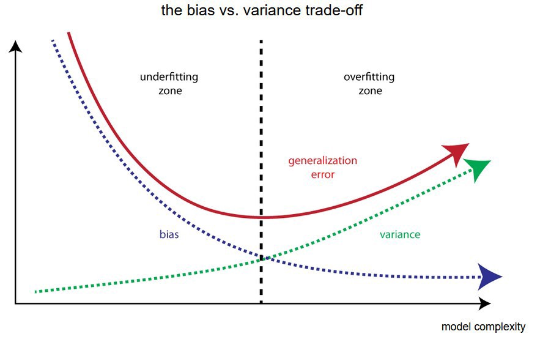

image.png

※ 이미지 출처: https://aman.ai/primers/ai/bias-variance-tradeoff/

### 편향과 분산에 영향을 주는 요소

1. 모델의 복잡도: 단일 측정 요소(estimator)가 출력을 도출하기 위한 요소의 수

> 입력 변수의 수, Parameter의 수, 의사 결정 나무의 노드수, 지지 벡터(Support vector)의 수

**→ 모델의 복잡도를 높힐 수록 편향이 낮아지는 경향이 있고, 분산은 높아지는 경향이 있습니다.**

2. 모델의 측정 요소(estimator)의 수: 모델의 출력을 집계 내기 위해 할당된 측정 요소의 수

> Random Forest에서 의사결정나무의 수, 최근접이웃의 수

**→ 모델의 측정 요소를 늘릴 수록 분산은 낮아지는 경향이 있습니다.**

3. 파라메터의 절대 크기(Magnitude)

> 선형 회귀 계수의 크기, 인공 신경망의 가중치 크기

**→ 파라메터의 절대 크기가 클수록 분산이 높아지는 경향이 있습니다.**

## 2. 과적합(Overfitting)과 과소적합(Underfitting)

1. **과적합(Overfitting)**: 모델이 학습데이터에 지나지게 맞추어져서 일반화 성능이 떨어진 상태입니다.
- 분산이 높거나 편향이 낮을 경우에 쉽게 발생합니다.
- 데이터가 지닌 패턴과 모델이 나타내는 패턴의 차이가 클수록 쉽게 발생합니다.

▷ 모델의 설정을 바꾸어 데이터에 보다 적합한 형태로 바꿉니다.

▷ 모델에 맞게 데이터를 바꿉니다.

- 학습데이터와 평가데이터의 차이가 클 경우 쉽게 발생합니다.

▷ 속성 공학을 통해 학습데이터와 평가데이터의 패턴을 반영할 수 있는 형태의 변수들을 만들어 줍니다.

- 데이터가 지닌 특성(패턴)을 나타내기에 데이터 수가 충분하지 않을 경우 쉽게 발생합니다.

▷ 데이터의 수를 늘립니다.

▷ 모델의 복잡도를 낮추어 봅니다.

- 부적절한 입력 변수가 포함이 되어 있을 경우 쉽게 발생합니다.

▷ 속성 선택을 통해 적절한 변수를 뽑아냅니다.

- 이상치나 노이즈에 의해 데이터에 오염이 심할수록 쉽게 발생합니다.

▷ 데이터 클린징 통해 이상치와 노이즈의 영향을 최소화 합니다.

2. **과소적합(Underfitting)**: 모델이 학습데이터에 맞추어지지 않아 일반화 성능이 떨어진 상태입니다.
- 분산이 낮거나 편향이 클 경우에 쉽게 발생합니다.
- 모델의 손실을 낮추는 최적화 과정이 제대로 이루어지지 않았을 경우 발생합니다.

▷ 학습 과정을 추가적으로 진행하여 모델을 좀 더 학습데이터에 맞춥니다.

- 모델의 복잡도를 높혀 학습 데이터를 좀 더 반영할 수 있도록 합니다.

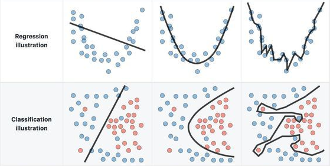

image.png

https://aman.ai/primers/ai/bias-variance-tradeoff/

**[Ex.1]**

K-최근접 이웃모델의 근접이웃의 수가 많을 수로 편향은 높아지고, 분산은 낮아집니다.

df_berry 에서 yield를 예측하는 K-최근접 이웃모델의 근접이웃 수에 따른 분산의 변화를 살펴봅니다.

전체 데이터를 80% 학습 데이터 df_train, 20%는 평가 데이터 df_test로 나눕니다.

이에 따른 학습데이터의 지표와 평가데이터의 지표를 살펴 봅니다.

입력 변수는 정규화(Normalization, Min-Max Scaling)를 합니다.

성능 지표는: 평균제곱오차(MSE, Mean Squared Error)를 사용합니다.

```r
library(caret)
# 80%는 학습 20%는 평가셋으로 나눕니다.
set.seed(123)
trainIndex <- createDataPartition(seq_len(nrow(df_berry)), p = 0.8, list = FALSE)
df_train <- df_berry[trainIndex, ]
df_test <- df_berry[-trainIndex, ]
```

```r
# 입력 변수 리스트를 만듭니다.
X_cols <- setdiff(names(df_berry), 'yield')

# MinMax Scaler를 생성합니다.
preproc <- preProcess(df_train[, X_cols], method = c("range"))

# 학습 데이터의 입력 변수를 변환하여 X_train 디자인 행렬을 만듭니다.
X_train <- as.data.frame(predict(preproc, df_train[, X_cols]))
y_train <- df_train$yield

# 평가 데이터의 입력 변수를 변환하여 X_test 디자인 행렬을 만듭니다.
X_test <- as.data.frame(predict(preproc, df_test[, X_cols]))
y_test <- df_test$yield
```

```r
# 결과를 저장할 리스트를 초기화합니다.
v <- numeric(30)
mse_train <- numeric(30)
mse_test <- numeric(30)

# 1 ~ 30개(최소 이웃) 까지 반복시킵니다.
for (i in 1:30) {
  knn_model <- knnreg(X_train, y_train, k = i)

  y_train_hat <- predict(knn_model, X_train)
  y_test_hat <- predict(knn_model, X_test)

  # 모델의 학습 데이터에 대한 출력의 분산을 기록합니다.
  v[i] <- var(y_train_hat)

  # 학습셋에 대한 성능을 기록합니다.
  mse_train[i] <- mean((y_train_hat - y_train)^2)

  # 평가셋에 대한 성능을 기록합니다.
  mse_test[i] <- mean((y_test_hat - y_test)^2)
}
```

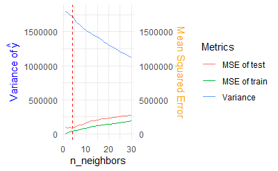

```r
# 데이터를 데이터 프레임으로 변환
df <- data.frame(
  n_neighbors = 1:30,
  Variance = c(v),
  MSE_Train = c(mse_train),
  MSE_Test = c(mse_test)
)

# 최적의 k 찾기
optimal_k <- which.min(mse_test)

# 그래프 출력
ggplot(df, aes(x = n_neighbors)) +
  geom_line(aes(y = Variance, color = 'Variance')) +
  geom_vline(xintercept = optimal_k, linetype = "dashed", color = "red") +
  geom_line(aes(y = MSE_Train, color = 'MSE of train')) +
  geom_line(aes(y = MSE_Test, color = 'MSE of test')) +
  scale_y_continuous(
    name = expression("Variance of" ~ hat(y)),
    sec.axis = sec_axis(~., name = "Mean Squared Error")
  ) +
  labs(
    x = 'n_neighbors',
    color = 'Metrics'
  ) +
  theme_minimal() +
  theme(
    axis.title.y.right = element_text(color = "orange"),
    axis.title.y.left = element_text(color = "blue")
  )
```

### 과적합의 진단

검증을 통해서 합니다.

- 학습데이터에 더 맞출수록 검증 데이터에 대한 성능이 떨어지게 되면 과적합이 진행된 것입니다.

**[Ex.2]**

Ex.1에서 학습 후 평가 이전에 최적합 상태를 보여주는 근접 이웃수를 검증을 통해 찾는 과정을 추가합니다.

검증 방법: 5겹 교차검증(5-fold cross validation)

```r
# KFold 설정
set.seed(123)
folds <- createFolds(y_train, k = 5)

eval_model <- function(reg, ...) {
  # 결과를 저장할 리스트 초기화
  results <- list()

  # 각 폴드에 대해 모델 학습 및 평가
  for (i in seq_along(folds)) {
    fold <- folds[[i]]

    # 학습 및 검증 데이터 분리
    X_train_fold <- X_train[-fold, ]
    y_train_fold <- y_train[-fold]
    X_test_fold <- X_train[fold, ]
    y_test_fold <- y_train[fold]

    # KNN 모델 학습
    knn_model <- reg(X_train_fold, y_train_fold, ...)

    # 예측 수행
    y_train_pred <- predict(knn_model, X_train_fold)
    y_test_pred <- predict(knn_model, X_test_fold)

    # MSE 계산
    train_mse <- mean((y_train_fold - y_train_pred)^2)
    test_mse <- mean((y_test_fold - y_test_pred)^2)

    # 결과 저장
    results[[i]] <- data.frame(Fold = i, TrainMSE = train_mse, TestMSE = test_mse)
  }

  # 결과를 데이터 프레임으로 변환
  eval_results <- do.call(rbind, results)

  # 학습 평균, 학습 표준편차, 검증 평균, 검증 표준편차 반환
  return(c(mean(eval_results$TrainMSE), sd(eval_results$TrainMSE), mean(eval_results$TestMSE), sd(eval_results$TestMSE)))
}

test_model <- function(reg, ...) {
  # 모델 학습
  model <- train(X_train, y_train, method = reg, trControl = trainControl(method = "none"), metric = "RMSE", ...)
  # 평가 데이터에 대한 예측
  prd <- predict(model, X_test)
  return(mean((prd - y_test)^2)) # MSE
}
```

```r
eval_model(knnreg, k=1)
```

```
[1]      0.00      0.00 108674.29  21313.58
```

```r
# 이웃 수 목록
n_neighbors_list <- 1:30

# 결과를 저장할 벡터 초기화
mse_train <- numeric(length(n_neighbors_list))
mse_validate <- numeric(length(n_neighbors_list))

# 각 이웃 수에 대해 교차 검증 수행
for (i in n_neighbors_list) {
  result  <- eval_model(knnreg, k = i)
  mse_train[i] = result[1]
  mse_validate[i] = result[3]
}

# 결과 출력
cat("MSE Train:\n")
```

```
MSE Train:
```

```r
print(mse_train)
```

```
 [1]      0.00  27744.19  39480.43  49822.42  59090.67  67982.01  77616.82  86919.12  96495.18 105237.00
[11] 112600.45 119371.79 125639.49 131798.07 137476.03 143795.56 149279.23 155420.12 161870.13 168989.90
[21] 174888.60 180077.56 187054.94 193822.23 200694.53 207026.64 214439.14 220528.63 228148.14 235209.83
```

```r
cat("MSE Validate:\n")
```

```
MSE Validate:
```

```r
print(mse_validate)
```

```
 [1] 108674.29  94002.69  85001.40  84707.10  93571.39  99853.22 106668.64 118765.22 126628.45 132171.18
[11] 138694.69 146076.03 148828.38 153469.56 161322.34 165387.45 170211.03 176306.59 181444.61 186472.11
[21] 192235.10 199291.29 205720.22 212075.69 216434.55 223634.25 231417.23 238218.17 245114.25 253128.36
```

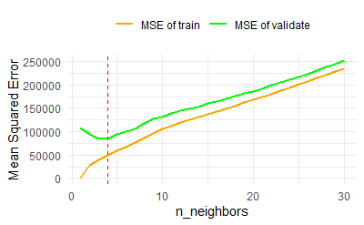

```r
# 결과를 데이터 프레임으로 변환
results_df <- data.frame(
  n_neighbors = n_neighbors_list,
  MSE_Train = mse_train,
  MSE_Validate = mse_validate
)

# 최소 검증 MSE 값을 갖는 이웃 수
optimal_k <- n_neighbors_list[which.min(mse_validate)]

# 그래프 출력
ggplot(results_df, aes(x = n_neighbors)) +
  geom_line(aes(y = MSE_Train, color = 'MSE of train'), size = 1) +
  geom_line(aes(y = MSE_Validate, color = 'MSE of validate'), size = 1) +
  geom_vline(xintercept = optimal_k, linetype = "dashed", color = "red") +
  labs(
    x = 'n_neighbors',
    y = 'Mean Squared Error',
    color = 'Metrics'
  ) +
  scale_color_manual(values = c('MSE of train' = 'orange', 'MSE of validate' = 'green')) +
  theme_minimal() +
  theme(
    legend.position = "top",
    legend.title = element_blank()
  )
```

### 모델 검증 결과 분석

- 모델의 개선 방향을 찾기 위해, 모델의 예측 오차의 양상을 살펴보고, 개선 방안을 마련합니다.

**[Ex.3]**

[Ex.2]의 교차 검증에서의 검증 데이터의 예측 결과의 잔차를 시각화해봅니다.

```r
# KFold 설정
set.seed(123)
folds <- createFolds(y_train, k = 5)

# 검증 데이터들의 예측 결과를 뽑아 주는 함수
cross_val_predict <- function(reg, ...) {
  y_cv <- numeric(length(y_train))

  # 각 폴드에 대해 모델 학습 및 평가
  for (i in seq_along(folds)) {
    fold <- folds[[i]]

    # 학습 및 검증 데이터 분리
    X_train_fold <- X_train[-fold, ]
    y_train_fold <- y_train[-fold]
    X_test_fold <- X_train[fold, ]

    # KNN 모델 학습
    model <- reg(X_train_fold, y_train_fold, ...)

    # 검증 데이터에 대한 예측 수행
    y_cv[fold] <- predict(model, X_test_fold)
  }

  return(y_cv)
}

y_cv <- cross_val_predict(knnreg, k = 2)
```

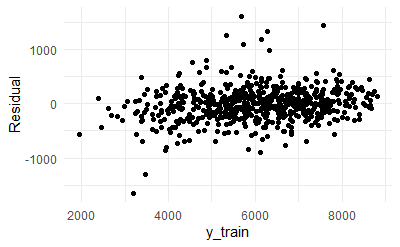

```r
# 잔차 계산
resid <- y_train - y_cv

# 데이터 프레임 생성
resid_df <- data.frame(y_train = y_train, resid = resid)

# 잔차 플롯 생성
ggplot(resid_df, aes(x = y_train, y = resid)) +
  geom_point() +
  labs(x = "y_train", y = "Residual") +
  theme_minimal()
```

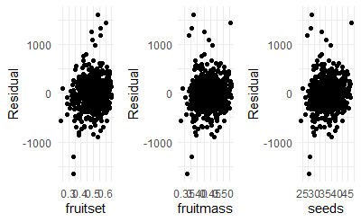

```r
library(gridExtra)
# 데이터 프레임 생성
resid_df <- data.frame(y_train = y_train, resid = resid, fruitset = df_train$fruitset, fruitmass = df_train$fruitmass, seeds = df_train$seeds)

# 잔차 플롯 생성
p1 <- ggplot(resid_df, aes(x = fruitset, y = resid)) +
  geom_point() +
  labs(x = "fruitset", y = "Residual") +
  theme_minimal()

p2 <- ggplot(resid_df, aes(x = fruitmass, y = resid)) +
  geom_point() +
  labs(x = "fruitmass", y = "Residual") +
  theme_minimal()

p3 <- ggplot(resid_df, aes(x = seeds, y = resid)) +
  geom_point() +
  labs(x = "seeds", y = "Residual") +
  theme_minimal()

# 여러 플롯을 한 레이아웃에 배치
grid.arrange(p1, p2, p3, ncol = 3)
```

**[Ex.5]**

KNN은 데이터의 밀도에 따라 영향도가 있습니다. PCA로 2차원으로 축소해보고 데이터의 밀집도에 따른 성능을 살펴봅니다.

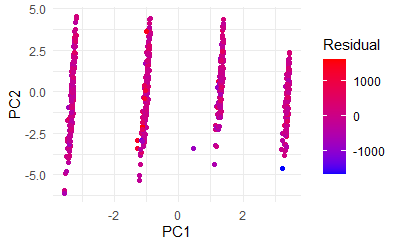

```r
# PCA 수행
pca <- prcomp(X_train, scale. = TRUE)
pca_val <- pca$x[, 1:2]

# 데이터 프레임 생성
pca_df <- data.frame(PC1 = pca_val[, 1], PC2 = pca_val[, 2], Residual = resid)

# PCA 결과 시각화
ggplot(pca_df, aes(x = PC1, y = PC2, color = Residual)) +
  geom_point() +
  scale_color_gradient(low = "blue", high = "red") +
  labs(x = "PC1", y = "PC2", color = "Residual") +
  theme_minimal()
```

## 3. 최적 모델 선택

### 하이퍼 파라메터 최적화(Hyper Parameter Optimization)

최적의 성능을 보이는 머신러닝 모델의 설정을 탐색합니다.

→ 모델이 나타내는 데이터의 형태. Ex) SVM의 Kernel 함수, 인공신경망의 신경망 구성, …

→ 모델의 복잡도를 탐색. Ex) 의사결정나무의 나무의 최대깊이, 리프노드 수, …

→ 모델의 파라메터(계수, 가중치, …)의 절대 크기에 대한 규제(Regularization) 계수

→ …

#### Grid Search

여러 하이퍼 파라메터간의 최적의 조합을 찾아내는 방법입니다.

하이퍼 파라메터 별로 탐색하고자 하는 값들을 설정하고,

여러 하이퍼 파라메터에서 조합할 수 있는 경우에 대해서 성능을 측정합니다.

**[Ex.6]**

df_train에서 다음 Random Forest Regressor 하이퍼 파라메터 설정에서 최적의 성능을 보이는 조합을 찾아 봅니다.

[output not shown]

검증 방법: 5겹 교차검증(5 fold cross validation)

성능 지표: 평균절대오차(MAE, Mean Absolute Error)

```r
library(randomForest)
eval_model_mae <- function(reg, ...) {
  # 결과를 저장할 리스트 초기화
  results <- list()

  # 각 폴드에 대해 모델 학습 및 평가
  for (i in seq_along(folds)) {
    fold <- folds[[i]]

    # 학습 및 검증 데이터 분리
    X_train_fold <- X_train[-fold, ]
    y_train_fold <- y_train[-fold]
    X_test_fold <- X_train[fold, ]
    y_test_fold <- y_train[fold]

    # 모델 학습
    model <- reg(X_train_fold, y_train_fold, ...)

    # 예측 수행
    y_train_pred <- predict(model, X_train_fold)
    y_test_pred <- predict(model, X_test_fold)

    # MSE 계산
    train_mae <- mean(abs(y_train_fold - y_train_pred))
    test_mae <- mean(abs(y_test_fold - y_test_pred))

    # 결과 저장
    results[[i]] <- data.frame(Fold = i, TrainMAE = train_mae, TestMAE = test_mae)
  }

  # 결과를 데이터 프레임으로 변환
  eval_results <- do.call(rbind, results)

  # 학습 평균, 학습 표준편차, 검증 평균, 검증 표준편차 반환
  return(c(mean(eval_results$TrainMAE), sd(eval_results$TrainMAE), mean(eval_results$TestMAE), sd(eval_results$TestMAE)))
}

# 그리드 검색을 위한 하이퍼파라미터 그리드 설정
param_grid <- expand.grid(
  ntree = c(50, 70, 100),
  maxnodes = c(9, 10, 11),
  nodesize = c(2, 4)
)

# 그리드 검색 수행
grid_search_results <- list()

for (i in 1:nrow(param_grid)) {
  params <- param_grid[i, ]
  res <- eval_model_mae(
    randomForest,
    ntree = params$ntree,
    maxnodes = params$maxnodes,
    nodesize = params$nodesize
  )

  grid_search_results[[i]] <- c(params, TrainMAE = res[1], TrainSD = res[2], TestMAE = res[3], TestSD = res[4])
}

# 결과를 데이터 프레임으로 변환
df_grid_search_results <- do.call(rbind, grid_search_results)
df_grid_search_results <- as.data.frame(df_grid_search_results)

df_grid_search_results[] <- lapply(df_grid_search_results, function(x) as.numeric(x))

# 최적의 하이퍼파라미터 조합 출력
print(df_grid_search_results)
```

| ntree | maxnodes | nodesize | TrainMAE | TrainSD | TestMAE | TestSD |
| --- | --- | --- | --- | --- | --- | --- |
| 50 | 9 | 2 | 201.5637 | 8.861199 | 220.2621 | 15.93563 |
| 70 | 9 | 2 | 198.2981 | 5.471522 | 221.7959 | 20.22163 |
| 100 | 9 | 2 | 203.1654 | 2.614478 | 223.8984 | 17.29024 |
| 50 | 10 | 2 | 199.1009 | 3.425439 | 221.2880 | 16.04033 |
| 70 | 10 | 2 | 197.5289 | 5.481365 | 221.4366 | 16.05798 |
| 100 | 10 | 2 | 192.5683 | 4.241058 | 212.3636 | 12.62421 |
| 50 | 11 | 2 | 186.9609 | 4.324529 | 211.3479 | 16.70381 |
| 70 | 11 | 2 | 188.1406 | 5.286275 | 208.2409 | 17.39378 |
| 100 | 11 | 2 | 188.8095 | 4.303245 | 209.7538 | 15.09386 |
| 50 | 9 | 4 | 210.6784 | 11.364046 | 232.7668 | 24.27085 |

[output cut: 8 more lines]

```r
best_params <- df_grid_search_results[which.min(df_grid_search_results$TestMAE), ]
print(as.data.frame(best_params))
```

|  | ntree | maxnodes | nodesize | TrainMAE | TrainSD | TestMAE | TestSD |
| --- | --- | --- | --- | --- | --- | --- | --- |
| 18 | 100 | 11 | 4 | 182.6226 | 1.307777 | 205.0397 | 16.05818 |

```r
NA
```

## 4. 속성 부분집합 선택(Feature Subset Selection)

### 필터(Filter) 방법

입력 변수(속성)와 대상 변수와의 연관성을 측정하고 높은 연관성을 갖는 변수를 우선으로 선택합니다.

대표적인 연관성 지표로 상관도, 정보 이득, 카이제곱 통계량 등이 있습니다.

**[Ex.7]**

[Ex 1]에서 제작한 입력 변수를 정규화 처리한 데이터인 X_train과

대상 데이터인 y_train의 피어슨 상관도를 기준으로 상관도가 높은 입력 변수(속성)을 우선으로

5개에서 16개까지 선택하여 성능을 측정했을 때,

가장 좋은 성능을 보일 때의 선택한 입력 변수의 수를 구해 봅니다.

max_depth: 11, min_samples_leaf: 2, n_estimators: 70 의 Random Forest Regressor를 사용합니다

검증 방법: 5겹 교차 검증(5-fold cross validation)

성능 측정 지표: 평균절대오차(MAE, Mean Absolute Error)

```r
# 피어슨 상관 계수를 사용한 피처 선택 함수
get_corr <- function(X, y) {
  scores <- apply(X, 2, function(col) abs(cor(col, y)))
  return(scores)
}

eval_model_mae2 <- function(reg, X_sel, ...) {
  # 결과를 저장할 리스트 초기화
  results <- list()

  # 각 폴드에 대해 모델 학습 및 평가
  for (i in seq_along(folds)) {
    fold <- folds[[i]]

    # 학습 및 검증 데이터 분리
    X_train_fold <- X_train[-fold, X_sel]
    y_train_fold <- y_train[-fold]
    X_test_fold <- X_train[fold, X_sel]
    y_test_fold <- y_train[fold]

    # 모델 학습
    model <- reg(X_train_fold, y_train_fold, ...)

    # 예측 수행
    y_train_pred <- predict(model, X_train_fold)
    y_test_pred <- predict(model, X_test_fold)

    # MSE 계산
    train_mae <- mean(abs(y_train_fold - y_train_pred))
    test_mae <- mean(abs(y_test_fold - y_test_pred))

    # 결과 저장
    results[[i]] <- data.frame(Fold = i, TrainMAE = train_mae, TestMAE = test_mae)
  }

  # 결과를 데이터 프레임으로 변환
  eval_results <- do.call(rbind, results)

  # 학습 평균, 학습 표준편차, 검증 평균, 검증 표준편차 반환
  return(c(mean(eval_results$TrainMAE), sd(eval_results$TrainMAE), mean(eval_results$TestMAE), sd(eval_results$TestMAE)))
}


# 그리드 검색 수행
sel_results <- list()

for (i in 5:16) {
  # 피처 선택
  scores <- get_corr(X_train, y_train)
  selected_features <- order(scores, decreasing = TRUE)[1:i]
  res <- eval_model_mae2(
    randomForest,
    mtry = i,
    ntree = 70,
    maxnodes = 11,
    nodesize = 2
  )
  sel_results[[i]] <- c(i, TrainMAE = res[1], TrainSD = res[2], TestMAE = res[3], TestSD = res[4])
}
# 결과를 데이터 프레임으로 변환
df_sel_results <- do.call(rbind, sel_results)
df_sel_results <- as.data.frame(df_sel_results)

df_sel_results[] <- lapply(df_sel_results, function(x) as.numeric(x))

# 최적의 하이퍼파라미터 조합 출력
print(df_sel_results)
```

| V1 | TrainMAE | TrainSD | TestMAE | TestSD |
| --- | --- | --- | --- | --- |
| 5 | 189.5053 | 5.023156 | 211.3856 | 13.623009 |
| 6 | 177.5037 | 3.971903 | 199.4995 | 12.225771 |
| 7 | 169.5383 | 2.894269 | 192.0254 | 8.660064 |
| 8 | 167.3881 | 2.355893 | 193.1767 | 9.933184 |
| 9 | 165.4693 | 3.596192 | 189.3738 | 6.961606 |
| 10 | 166.1019 | 1.698215 | 190.0044 | 6.043283 |
| 11 | 166.2772 | 2.245468 | 188.4489 | 7.428125 |
| 12 | 167.8707 | 1.805666 | 191.1796 | 5.330016 |
| 13 | 168.8950 | 2.685428 | 192.6026 | 6.698497 |
| 14 | 169.8211 | 1.618390 | 192.6284 | 6.655219 |

[output cut: 2 more lines]

```r
best_params <- df_sel_results[which.min(df_sel_results$TestMAE), ]
print(as.data.frame(best_params))
```

|  | V1 | TrainMAE | TrainSD | TestMAE | TestSD |
| --- | --- | --- | --- | --- | --- |
| 7 | 11 | 166.2772 | 2.245468 | 188.4489 | 7.428125 |

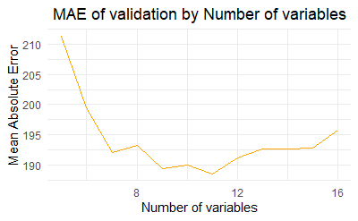

```r
# 플롯 생성
ggplot(df_sel_results, aes(x = V1, y = TestMAE)) +
  geom_line(color = 'orange') +
  labs(x = 'Number of variables', y = 'Mean Absolute Error') +
  theme_minimal() +
  ggtitle('MAE of validation by Number of variables') +
  theme(plot.title = element_text(hjust = 0.5)) # 제목 가운데 정렬
```

### 웨퍼(Wrapper)방법

사용할 모델에 선택한 변수로 검증을 하여 가장 좋은 성능을 내는 변수 조합을 찾습니다.

80%는 학습데이터(X_iris_train, y_iris_train)로, 20%(X_iris_test, y_iris_test)로 나누어 봅니다.

이 때, 계층적 선택법을 사용합니다.

```r
library(datasets)

# Iris 데이터 로드
data(iris)

# 데이터와 타겟 변수 분리
X_iris <- iris[, 1:4]
y_iris <- iris[, 5]

# 학습 및 평가 세트로 나누기 (80% 학습, 20% 평가)
set.seed(123)
trainIndex <- createDataPartition(y_iris, p = 0.8, list = FALSE)
X_iris_train <- X_iris[trainIndex, ]
X_iris_test <- X_iris[-trainIndex, ]
y_iris_train <- y_iris[trainIndex]
y_iris_test <- y_iris[-trainIndex]

# 결과 확인
print(dim(X_iris_train)) # 학습 세트 크기
```

```
[1] 120   4
```

```r
print(dim(X_iris_test))  # 평가 세트 크기
```

```
[1] 30  4
```

```r
print(table(y_iris_train)) # 학습 세트 타겟 분포
```

```
y_iris_train
    setosa versicolor  virginica
        40         40         40
```

```r
print(table(y_iris_test))  # 평가 세트 타겟 분포
```

```
y_iris_test
    setosa versicolor  virginica
        10         10         10
```

#### All Subsets

입력 변수에서 조합할 수 있는 모든 변수의 조합을 사용합니다.

※ 시간 복잡도가 $O(2^n)$ (n은 입력 변수의 수)이므로 입력 변수가 많아 질수록, 수행 속도가 급격하게 증가합니다.

**[Ex.8]**

학습 데이터 {X_iris_train, y_iris_train} 에서 최적의 입력 변수 조합을 All Subsets 방법으로 찾아 봅니다.

성능 지표는 정확도(Accuracy)입니다. Wrapper는 로지스틱 회귀모델을 사용합니다.

찾은 변수 조합으로 평가 데이터 {X_iris_test, Y_iris_test}의 성능을 측정 합니다.

```r
library(nnet)  # for multinom function
# 평가 함수 정의
eval_model_accuracy <- function(clf, X_sel, ...) {
  results <- list()

  # Stratified K-Fold 설정
  set.seed(123)
  folds <- createFolds(y_iris_train, k = 5)
  # 각 폴드에 대해 모델 학습 및 평가
  for (i in seq_along(folds)) {
    fold <- folds[[i]]

    # 학습 및 검증 데이터 분리
    X_train_fold <- X_iris_train[-fold, X_sel, drop = FALSE]
    y_train_fold <- y_iris_train[-fold]
    X_test_fold <- X_iris_train[fold, X_sel, drop = FALSE]
    y_test_fold <- y_iris_train[fold]

    # 모델 학습
    model <- clf(X_train_fold, y_train_fold, ...)

    # 예측 수행
    y_test_pred <- predict(model, X_test_fold)

    # 정확도 계산
    train_accuracy <- mean(predict(model, X_train_fold) == y_train_fold)
    test_accuracy <- mean(y_test_pred == y_test_fold)

    # 결과 저장
    results[[i]] <- data.frame(Fold = i, TrainAccuracy = train_accuracy, TestAccuracy = test_accuracy)
  }
  # 결과를 데이터 프레임으로 변환
  eval_results <- do.call(rbind, results)

    # 학습 평균, 학습 표준편차, 검증 평균, 검증 표준편차 반환
  return(c(mean(eval_results$TrainAccuracy), sd(eval_results$TrainAccuracy), mean(eval_results$TestAccuracy), sd(eval_results$TestAccuracy)))
}

# 피처 조합과 성능 저장 리스트 초기화
scores <- list()
subsets <- list()

# 로지스틱 회귀 모델 설정
logistic_reg <- function(X, y, ...) {
  multinom(y ~ ., data = data.frame(X, y), ...)
}

# 피처 조합 생성 및 교차 검증 수행
for (i in 1:4) {
  comb <- combn(1:4, i, simplify = FALSE)
  for (j in comb) {
    X_cols <- unlist(j)
    subsets <- append(subsets, list(X_cols))

    res <- eval_model_accuracy(
      logistic_reg,
      X_sel = X_cols,
      trace = FALSE
    )

    scores <- append(scores, list(c(i, TrainAccuracy = res[1], TrainSD = res[2], TestAccuracy = res[3], TestSD = res[4])))
  }
}

# 결과를 데이터 프레임으로 변환
df_results <- do.call(rbind, scores)
df_results <- as.data.frame(df_results)

# 최적의 피처 조합 출력
print(df_results)
```

| V1 | TrainAccuracy | TrainSD | TestAccuracy | TestSD |
| --- | --- | --- | --- | --- |
| 1 | 0.7479167 | 0.023753655 | 0.7500000 | 0.08333333 |
| 1 | 0.5583333 | 0.038696199 | 0.5333333 | 0.12638126 |
| 1 | 0.9583333 | 0.007365696 | 0.9583333 | 0.02946278 |
| 1 | 0.9666667 | 0.011410887 | 0.9666667 | 0.04564355 |
| 2 | 0.8166667 | 0.026145626 | 0.8000000 | 0.08014743 |
| 2 | 0.9770833 | 0.013581672 | 0.9500000 | 0.01863390 |
| 2 | 0.9625000 | 0.015797657 | 0.9666667 | 0.04564355 |
| 2 | 0.9625000 | 0.009316950 | 0.9583333 | 0.02946278 |
| 2 | 0.9625000 | 0.011876827 | 0.9583333 | 0.05892557 |
| 2 | 0.9750000 | 0.009316950 | 0.9583333 | 0.04166667 |

[output cut: 5 more lines]

```r
best_params <- df_results[which.max(df_results$TestAccuracy), ]
print(as.data.frame(best_params))
```

|  | V1 | TrainAccuracy | TrainSD | TestAccuracy | TestSD |
| --- | --- | --- | --- | --- | --- |
| 4 | 1 | 0.9666667 | 0.01141089 | 0.9666667 | 0.04564355 |

#### 전진선택법(Forward Selection)과 후진제거법(Backward Elimination)

- 연산 정의
1. 전진 선택: 선택하지 않은 속성들을 하나 씩 추가 해봤을 때 가장 좋은 성능을 보인 속성을 선택합니다.
2. 후진 제거: 선택한 속성들을 하나 씩 제거해 봤을 때 가장 좋은 성능을 보인 속성을 제거합니다.
- 선택법
1. 전진선택법(Forward Selection)
- 빈리스트에서 시작하여, 단계적으로 전진 선택을 합니다.
- 더이상 성능에 개선이 없거나 선택할 속성이 없다면 멈춥니다.
2. 단계적 전진선택법(Stepwise Forward Selection)
- 빈리스트에서 시작하여, 단계적으로 전진 선택을 하고, 후진 제거를 하여 성능에 개선이 있다면 제거를 합니다.
- 더이상 성능에 개선이 없거나 선택할 속성이 없다면 멈춥니다.
3. 후진제거법(Backward Elimination)
- 모든 속성 리스트에서 시작하여, 단계적으로 후진 제거를 합니다.
- 더이상 성능에 개선이 없거나 제거할 속성이 없다면 멈춥니다.
4. 단계적 후진제거법(Stepwise Backward Elimination)
- 모든 속성 리스트에서 시작하여, 단계적으로 후진 제거를 하고, 전진 선택을 하여 성능에 개선이 있다면 추가 합니다.
- 더이상 성능에 개선이 없거나 제거할 속성이 없다면 멈춥니다.

**[Ex.9]**

[Ex.8]에서 All Subsets 예제에서 All Subsets 대신 전진선택법, 단계적 전진선택법, 후진제거법, 단계적후진제거법을 수행해봅니다.

```r
forward_select <- function(X_all, X_subsets) {
  X_fwd <- lapply(setdiff(X_all, X_subsets), function(i) c(X_subsets, i))
  scores_fwd <- sapply(X_fwd, function(i) eval_model_accuracy(logistic_reg, i[[1]])[3])
  idx <- which.max(scores_fwd)
  return(list(subset = X_fwd[[idx]], score = scores_fwd[idx]))
}

backward_eliminate <- function(X_subsets) {
  if (length(X_subsets) < 2) {
    return(list(subset = NULL, score = -Inf))
  }

  X_bwd <- combn(X_subsets, length(X_subsets) - 1, simplify = FALSE)
  scores_bwd <- sapply(X_bwd, function(i) eval_model_accuracy(logistic_reg, i[[1]])[3])
  idx <- which.max(scores_bwd)
  return(list(subset = X_bwd[[idx]], score = scores_bwd[idx]))
}
```

```r
# 전진 선택법 구현
X_subsets <- list()  # 각 단계에 선택된 속성들을 남기기 위한 리스트
X_subsets[[1]] <- c()  # 초기 선택된 변수는 없음
scores <- c(-Inf)  # 초기 점수는 -무한대로 설정
X_all <- 1:ncol(X_iris_train)  # 모든 변수의 인덱스

while (TRUE) {
  if (length(X_subsets) == 0) {
    fwd_result <- forward_select(X_all, X_subsets)
  } else {
    fwd_result <- forward_select(X_all, X_subsets[[length(X_subsets)]])
  }
  X_best <- fwd_result$subset
  score <- fwd_result$score
  print(paste("Best subset:", toString(X_best), "with score:", score))  # 현 단계에서 가장 좋은 속성 조합 출력
  if (score <= scores[length(scores)]) {  # 성능에 개선이 없으면 종료
    break
  }
  scores <- c(scores, score)
  X_subsets <- append(X_subsets, list(X_best))
  if (length(X_best) == length(X_all)) {  # 모두 선택되어 더 이상 선택할 변수가 없을 경우 종료
    break
  }
}
```

```
[1] "Best subset: 4 with score: 0.966666666666667"
[1] "Best subset: 4, 1 with score: 0.966666666666667"
```

```r
# 최종 결과 출력
final_score <- scores[length(scores)]
final_subset <- X_subsets[[length(X_subsets)]]
final_features <- colnames(X_iris)[final_subset[[1]]]
print(paste("Final score:", final_score))
```

```
[1] "Final score: 0.966666666666667"
```

```r
print(paste("Final subset indices:", toString(final_subset)))
```

```
[1] "Final subset indices: 4"
```

```r
print(paste("Final subset features:", toString(final_features)))
```

```
[1] "Final subset features: Petal.Width"
```

```r
# 후진 제거법 구현
X_all <- 1:ncol(X_iris_train)  # 모든 변수의 인덱스
X_subsets <- list(X_all)  # 초기 변수 집합은 모든 변수를 포함
scores <- list(eval_model_accuracy(logistic_reg, X_all)[3])
while (TRUE) {
  bwd_result <- backward_eliminate(X_subsets[[length(X_subsets)]])
  X_best <- bwd_result$subset
  score <- bwd_result$score
  print(paste("Best subset:", toString(X_best), "with score:", score))  # 현 단계에서 가장 좋은 속성 조합 출력
  if (score <= scores[[length(scores)]]) {  # 성능에 개선이 없으면 종료
    break
  }
  scores <- append(scores, list(score))
  X_subsets <- append(X_subsets, list(X_best))
  if (length(X_best) == 1) {  # 더 이상 제외할 변수가 없으면 종료
    break
  }
}
```

```
[1] "Best subset: 1, 2, 3 with score: 0.75"
```

```r
# 최종 결과 출력
final_score <- scores[[length(scores)]]
final_subset <- X_subsets[[length(X_subsets)]]
final_features <- colnames(X_iris)[final_subset]
print(paste("Final score:", final_score))
```

```
[1] "Final score: 0.941666666666667"
```

```r
print(paste("Final subset indices:", toString(final_subset)))
```

```
[1] "Final subset indices: 1, 2, 3, 4"
```

```r
print(paste("Final subset features:", toString(final_features)))
```

```
[1] "Final subset features: Sepal.Length, Sepal.Width, Petal.Length, Petal.Width"
```

```r
# 단계적 전진 선택법 구현
X_subsets <- list()  # 각 단계에 선택된 속성들을 남기기 위한 리스트
X_subsets[[1]] <- c()  # 초기 선택된 변수는 없음
scores <- c(-Inf)  # 초기 점수는 -무한대로 설정
X_all <- 1:ncol(X_iris_train)  # 모든 변수의 인덱스

while (TRUE) {
  if (length(X_subsets) == 0) {
    fwd_result <- forward_select(X_all, X_subsets)
  } else {
    fwd_result <- forward_select(X_all, X_subsets[[length(X_subsets)]])
  }
  X_best <- fwd_result$subset
  score <- fwd_result$score
  print(paste("Best subset:", toString(X_best), "with score:", score))  # 현 단계에서 가장 좋은 속성 조합 출력

  if (score <= scores[length(scores)]) {  # 성능에 개선이 없으면 종료
    break
  }

  bwd_result <- backward_eliminate(X_best)  # 후진 제거 수행
  X_bwd <- bwd_result$subset
  bwd_score <- bwd_result$score

  if (score < bwd_score) {  # 후진 제거의 효과가 있다면 제거한 리스트 선택
    X_best <- X_bwd
    score <- bwd_score
    print(paste("Backward Elimination: ", bwd_score, toString(X_bwd)))
  }

  scores <- c(scores, score)
  X_subsets <- append(X_subsets, list(X_best))

  if (length(X_best) == length(X_all)) {  # 모두 선택되어 더 이상 선택할 변수가 없을 경우 종료
    break
  }
}
```

```
[1] "Best subset: 4 with score: 0.966666666666667"
[1] "Best subset: 4, 1 with score: 0.966666666666667"
```

```r
# 최종 결과 출력
final_score <- scores[length(scores)]
final_subset <- X_subsets[[length(X_subsets)]]
final_features <- colnames(X_iris)[final_subset[[1]]]
print(paste("Final score:", final_score))
```

```
[1] "Final score: 0.966666666666667"
```

```r
print(paste("Final subset indices:", toString(final_subset)))
```

```
[1] "Final subset indices: 4"
```

```r
print(paste("Final subset features:", toString(final_features)))
```

```
[1] "Final subset features: Petal.Width"
```

```r
# 단계적 후진 제거법 구현
X_all <- 1:ncol(X_iris_train)  # 모든 변수의 인덱스
X_subsets <- list(X_all)  # 초기 변수 집합은 모든 변수를 포함
scores <- list(eval_model_accuracy(logistic_reg, X_all)[3])
while (TRUE) {
  bwd_result <- backward_eliminate(X_subsets[[length(X_subsets)]])
  X_best <- bwd_result$subset
  score <- bwd_result$score
  print(paste("Best subset:", toString(X_best), "with score:", score))  # 현 단계에서 가장 좋은 속성 조합 출력

  if (score <= scores[[length(scores)]]) {  # 성능에 개선이 없으면 종료
    break
  }

  fwd_result <- forward_select(X_all, X_best)  # 전진 선택 수행
  X_fwd <- fwd_result$subset
  fwd_score <- fwd_result$score

  if (score < fwd_score) {  # 전진 선택의 효과가 있다면 선택
    X_best <- X_fwd
    score <- fwd_score
    print(paste("Forward Selection: ", fwd_score, toString(X_fwd)))
  }

  scores <- append(scores, list(score))
  X_subsets <- append(X_subsets, list(X_best))

  if (length(scores) == length(X_all) + 1) {  # 더 이상 선택할 변수가 없으면 종료
    break
  }
}
```

```
[1] "Best subset: 1, 2, 3 with score: 0.75"
```

```r
# 최종 결과 출력
final_score <- scores[[length(scores)]]
final_subset <- X_subsets[[length(X_subsets)]]
final_features <- colnames(X_iris)[final_subset]
print(paste("Final score:", final_score))
```

```
[1] "Final score: 0.941666666666667"
```

```r
print(paste("Final subset indices:", toString(final_subset)))
```

```
[1] "Final subset indices: 1, 2, 3, 4"
```

```r
print(paste("Final subset features:", toString(final_features)))
```

```
[1] "Final subset features: Sepal.Length, Sepal.Width, Petal.Length, Petal.Width"
```

### 장단점 비교

| 방법 | 장점 | 단점 |
| --- | --- | --- |
| Filter 방법 | 계산 비용이 낮고 빠릅니다. 대규모 데이터셋에도 적용하기 쉽습니다. 머신러닝 모델과 독립적으로 작동하므로 어떤 모델이든 적용 가능합니다. | 모델의 상호작용을 고려하지 않고 속성을 개별적으로 평가하기 때문에, 최적의 조합을 고려하지 않을 수 있습니다. |
| Wrapper 방법 | 속성 간 상호작용을 고려할 수 있어 더 좋은 성능을 얻을 수 있습니다. | 계산 비용이 매우 높습니다. |